# Exploring the BRFSS data

Guillermo Ulises Ortiz-Garin

11/8/2018

### Load packages

```r
library(ggplot2)
library(dplyr)
library(readxl)
library(car)
library(HH)
library(statsr)
library(GGally)
library(sjPlot)
library(sjmisc)
library(tinytex)
library(devtools)
```

### Load data

```r
load("brfss2013.RData")
```

## Part 1: Data

The BRFSS obtain their data through standardized surveys. They make a monthly survey and have a data big database of the surveys over the previous years, which helps to have a huge observation per variables through the time. Knowing the earlier, we can analyze how a variable behaves in a specific year or over the years, although, in we’ll only use the 2013 database. The survey was make by landline with telephone numbers or cellphones stratified selected by the density stratum. Because this data was collected by stratified random sampling, the results could be generalizable to the population from USA and some territories, also, having a big sample make easy brings a good parameter from this population of interest. Nevertheless, on one hand, this criterion which they used for the studio, enables to control some bias, but still, they cannot control some variables that could influence the answer of some participants, for example, someone could lie in the answers about drinking alcoholic drinks, for some social reason, also, it seems that the volunteer bias also could be present in the study.

## Part 2: Research questions

**Research quesion 1:**

How is the distribution of the answers of people about the hours they sleep and what are their summaries (Mean, Median, SD and so on) in EUA population?

**Research quesion 2:**

What proportion of the sample sleeps more than 4 hours and report a good health or a better? how does this difference looks like among sexes?

**Research quesion 3:**

Given the answer of the earlier question, use the binomial model to answer what is the probability that using random sample of 1000 people in EUA at least 600 people sleep more than 4 hours and have a good health or a better?

## Part 3: Exploratory data analysis

**Research quesion 1:** I’m interested in sleep time variable (sleptim1) and how is the data distribution, so, I type group function to look at this first:

```r
brfss2013%>%
  group_by(sleptim1) %>%
  summarise(count = n())
```

```
## # A tibble: 28 x 2
##    sleptim1  count
##       <int>  <int>
##  1        0      1
##  2        1    228
##  3        2   1076
##  4        3   3496
##  5        4  14261
##  6        5  33436
##  7        6 106197
##  8        7 142469
##  9        8 141102
## 10        9  23800
## # ... with 18 more rows
```

I could see all the values of the variable but something goes wrong because it supposes that the way in which the questions were asked just enable answer in values from 1 to 24. The result of the earlier command show me 10 rows and in the bottom of the result say “18 more rows”, so, I have 3 numbers more that could be a “finger error”" in the database. Let suppose that this won’t affect the variable distribution so I type a histogram ggplot function:

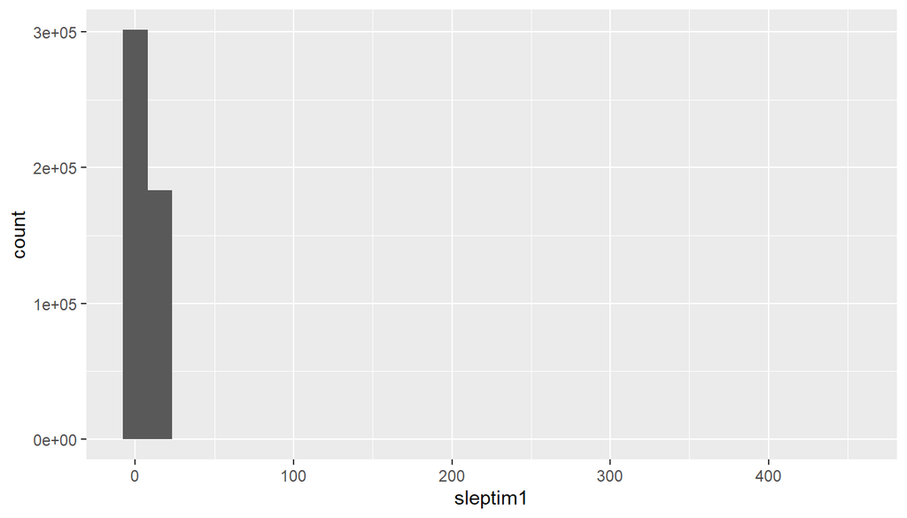

```r
ggplot(data = brfss2013, aes(x = sleptim1)) + geom_histogram ()
```

Apparently, the earlier values are affecting the visualization of the distribution for that’s the reason we see two solid bars on the left side. If our aim is just to visualize the distribution we can solve the apparent problem in a pretty easy way using function ggplot functions “xlim ()” ans “bins =” let see if the problem is solved

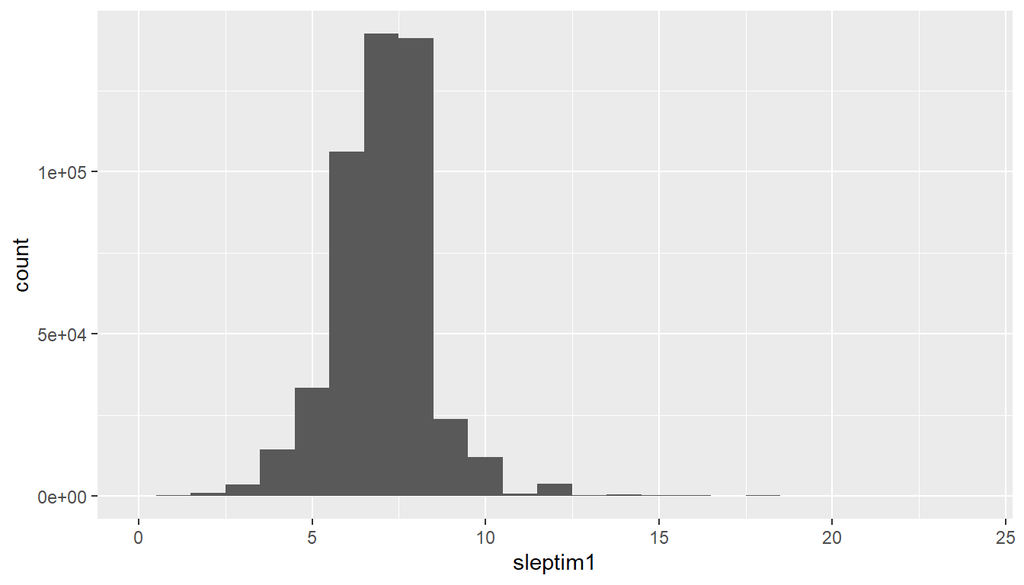

```r
ggplot(data = brfss2013, aes(x = sleptim1)) + geom_histogram (bins = 25) +xlim(c(0, 24))
```

In effect with this function we apparently solve the problem, but what happens if we want to know the numerical summaries as the mean or IQR of the variable, let see what happen. We can do that using an R function called “summary()”

```r
summary(brfss2013$sleptim1)
```

```
##    Min. 1st Qu.  Median    Mean 3rd Qu.    Max.    NA's
##   0.000   6.000   7.000   7.052   8.000 450.000    7387
```

or

```r
brfss2013 %>% summarise(sleepmean = mean(sleptim1), sleepmedian = median(sleptim1), sleepsd = sd(sleptim1), sleepmin = min(sleptim1), sleepmax = max(sleptim1))
```

```
##   sleepmean sleepmedian sleepsd sleepmin sleepmax
## 1        NA          NA      NA       NA       NA
```

as we can see the problem was not solved at all and it is affecting the real numerical summaries as Maximum and Minimum, for that reason the solution is to update the database with the filter function, but first I need to identify which values I need to delete. To see what what are those values, let’s see all the rows of this variable with the table function:

```r
table(brfss2013$sleptim1)
```

```
##
##      0      1      2      3      4      5      6      7      8      9     10
##      1    228   1076   3496  14261  33436 106197 142469 141102  23800  12102
##     11     12     13     14     15     16     17     18     19     20     21
##    833   3675    199    447    367    369     35    164     13     64      3
##     22     23     24    103    450
##     10      4     35      1      1
```

Now I can see that the error values are “0”, “103” and “450” which is pretty obvious because the question regards the hour per day, so, a value of 450 is impossible. The filter function will help us to delete those values:

```r
brfss2013 <- brfss2013 %>% filter(sleptim1 <= 24, sleptim1 >= 1)
```

As we can see the earlier command delete the rows with the values 0, 103 and 450 but as we can note that also delete rows with NA’s:

```r
table(brfss2013$sleptim1)
```

```
##
##      1      2      3      4      5      6      7      8      9     10     11
##    228   1076   3496  14261  33436 106197 142469 141102  23800  12102    833
##     12     13     14     15     16     17     18     19     20     21     22
##   3675    199    447    367    369     35    164     13     64      3     10
##     23     24
##      4     35
```

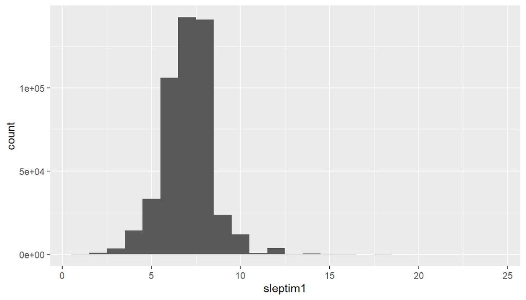

```r
ggplot(data = brfss2013, aes(x = sleptim1)) + geom_histogram (binwidth = 1)
```

and

```r
brfss2013 %>% summarise(sleepmean = mean(sleptim1), sleepmedian = median(sleptim1), sleepsd = sd(sleptim1), sleepmin = min(sleptim1), sleepmax = max(sleptim1))
```

```
##   sleepmean sleepmedian  sleepsd sleepmin sleepmax
## 1  7.051001           7 1.465953        1       24
```

Regarding our first question: it seems that the sleep time variable resembles a normal distribution. Because the “n” is very high this is not surprising, and helpful to this shape of the distribution we can get several conclusion about the EUA population and the sleep time by day giving the numerical summaries that we obtained.

**Research quesion 2:**

Now, we want to know what proportion of the sample sleeps more than 4 hours and report a good health or a better. First, we need to look at our next variable “genhlth”:

```r
brfss2013%>% group_by(genhlth) %>% summarise(count = n())
```

```
## # A tibble: 6 x 2
##   genhlth    count
##   <fct>      <int>
## 1 Excellent  84821
## 2 Very good 157833
## 3 Good      148299
## 4 Fair       65012
## 5 Poor       26639
## 6 <NA>        1781
```

We can see that is a different type of variable, it is a categorical variable. Knowing that and because we are also interested in the “sleptim1”" variable we can look how the people, of a given category, responded in that variable. We use a box plot.

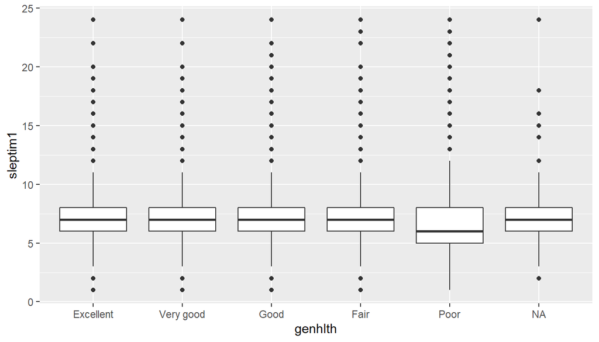

```r
ggplot(data=brfss2013, aes(x=genhlth, y=sleptim1)) + geom_boxplot()
```

We can see that all the categories have outliers and the medians are almost centered in the boxes except in the case of people which report a poor health, in this case, it looks like the distribution of that category is right-skewed. Nevertheless, for this work we are only interested in know how many people reported to sleep more than 4 hours and reported a good health or better. First, let’s see how many people sleep more than 4 hours: We’ll create a new variable called “gdsleptm” which represents what I specify earlier. For doing that we use the mutate function:

```r
 brfss2013 <- brfss2013 %>% mutate(gdsleptm = ifelse(sleptim1 <= 4, "bad sleep", "good sleep"))
```

We type the “group”" command to see it

```r
brfss2013 %>% group_by(gdsleptm) %>% summarise(count = n())
```

```
## # A tibble: 2 x 2
##   gdsleptm    count
##   <chr>       <int>
## 1 bad sleep   19061
## 2 good sleep 465324
```

We can see that 96% of the sample meet the criteria but remember we are interested in people that meet this criterion and also report a good, very good or excellent health. For that reason we create a new data frame called “Slepnddhlth” using the filter function:

```r
Slepnddhlth <- brfss2013 %>% filter(
  gdsleptm == "good sleep",
  genhlth =="Good" | gdsleptm == "Excellent" | gdsleptm== "Very good")
```

```r
Slepnddhlth %>% group_by(gdsleptm, genhlth) %>% summarise(count = n())
```

```
## # A tibble: 1 x 3
## # Groups:   gdsleptm [1]
##   gdsleptm   genhlth  count
##   <chr>      <fct>    <int>
## 1 good sleep Good    143114
```

Now I want to know how is the proportion of this criterion between sexes for that reason I’ll use a stacked bar plot to see between the sexes which one meets in more proportion that criterion.

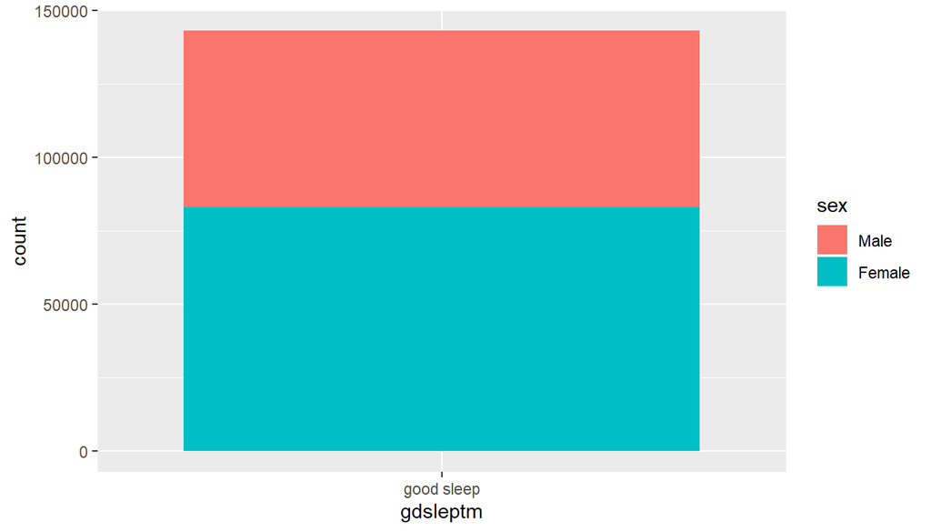

```r
ggplot(data=Slepnddhlth, aes(x=gdsleptm, fill=sex)) + geom_bar(position = "stack")
```

It seems that Females tend to report more that they feel a good health and also sleep more than 4 hours compared to men

```r
count(Slepnddhlth)/count(brfss2013)
```

```
##           n
## 1 0.2954551
```

**Research quesion 3:**

```r
dbinom(600:1000, size = 1000, prob = 0.2954551)
```

[output not shown]

[output cut: 66 more lines]

but wait. we have not interested just in a value, we are interested in the upper tail of the distribution. We’ll sum the probabilities from 600 to 1000 using the sum function.

```r
sum(dbinom(600:1000, size = 1000, prob = 0.2954551))
```

```
## [1] 1.977731e-88
```

We can conclude that we should expect a tinny probability given the binomial distribution.